# Observaing Tesla stock by using R

Site Bai

11/28/2017

### **Motivation:**

For my personal reason, I want to see the trend behind a specific stock and combine it with my economics  
background to understand the WSJ news about the stock. More specifically, truely use the R to explain what  
is taking place in the stock market and why works in such a way. And I am glad to show you how to do it in  
this post. Thank you for reading this post in advance.

[figure not shown]

### **Introduction:**

Are you tired of people talking about stock and you cannot since you do not even know a bit of stock? I am! This  
post is going to show you how to use powerful packages and functions of R to grasp the basic yet essential pattern  
of any stock you want. Actually, it is all about time. Time is the most fatcor ensuring success in business,  
especially in the stock market.Based on time seris, we could find the pattern from past and predcit the future.  
Let’s get started!

##### All packages you need with its version as below:

| Packages | Name | Version |
| --- | --- | --- |
| library(zoo) | zoo | version 1.8.0 |
| library(xts) | xts | version 0.10.0 |
| library(TTR) | TTR | version 0.23.2 |
| library(forecast) | forecast | version 8.2 |
| Rstudio | Rstudio | version 3.3.2 (2016-10-31) |

As the global warming more and more becomes a concern for every person living in this planet,eletric car seems to  
be a promise for a healthy and clean environment. Among many exsiting electric cars,Tesla motors is no doubt the  
league of the competitive electric car market. The eye-catching outline plus advanced engine, and the personal charisma of the founder,Elon Musk, will make Tesla more popular in the years ahead. How about Tesla’s stock? Does  
it will be as strong as its engines? Follow this post, you will find the answer.

###### I downloaded data from Yahoo! [Finance](https://finance.yahoo.com/quote/TSLA?p=TSLA). After cleaning data,I kept adjusted close price and the date index as follow. One more step before analysing the data, we need to convert data frame to the “xts” class, which could help us completing our analysis.

```r
dim(tesla)
```

```
## [1] 252   2
```

```r
rownames(tesla) <- tesla$Date
tesla$Date <- NULL
colnames(tesla) <- "Tesla"
```

###### You could see the class of tesla_stock is “xts zoo” since xts is part of the zoo.

```r
tesla_stock <- xts(tesla,order.by = as.Date(rownames(tesla),"%m/%d/%Y"))
head(tesla_stock)
```

```
##             Tesla
## 0016-11-29 189.57
## 0016-11-30 189.40
## 0016-12-01 181.88
## 0016-12-02 181.47
## 0016-12-05 186.80
## 0016-12-06 185.85
```

```r
class(tesla_stock)
```

```
## [1] "xts" "zoo"
```

###### Surprisingly, if you use the basic plot function to plot the tesla_stock, you will find a little different from what we have seen before. The time index is automatically displayed in the x_axis. Isn’t is amazing?

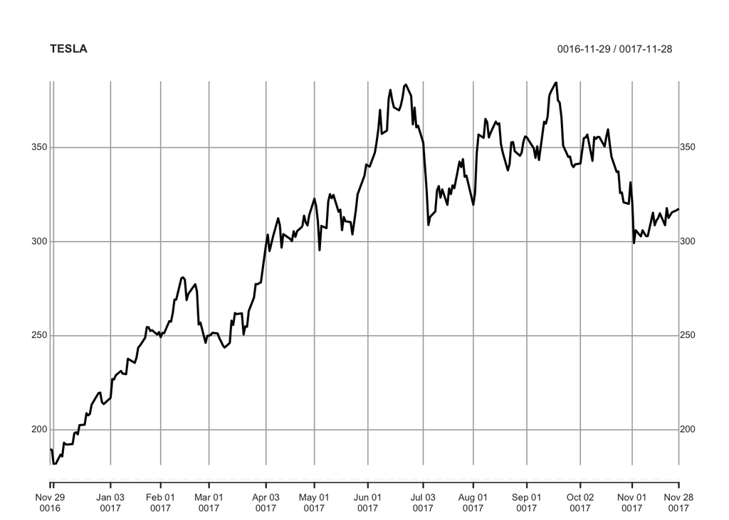

```r
plot(tesla_stock,main = "TESLA")
```

###### After viewing the fancy plot, what useful information we would get from it? Even though there are many flucations through time, the stock has a strong upward trend. That is all? Are you going to buy it based it? Of course not,we would like to focus on its return rate, which is more reliable for stock analysing.